# RareQ for scRNA & scATAC Multiome Data

Last edited: November 16, 2025

This tutorial demonstrates how to apply **RareQ** to a paired **scRNA-seq + scATAC-seq** dataset, using **Seurat** + **Signac** for preprocessing and multimodal integration.

## Load the data

```r
library(Seurat)
library(Signac)
library(RareQ)   # core method for rare-cell detection
library(dplyr)
library(ggplot2)
library(GenomicRanges)

# Read example data
# Please replace the path with your local "Tutorial_example" directory
dat = readRDS('Tutorial_example/data/Mouse_gdT.RDS')
```

This dataset contains both gene expression matrix (`dat$RNA`) and ATAC peak accessibility matrix (`dat$Peaks`) from mouse T cells. If your ATAC peak names don’t match `chr:start-end`, adapt the parsing below.

## Build Seurat object and add assays

We first create a Seurat object for RNA and then add ATAC as a ChromatinAssay so both modalities are contained in one Seurat object.

```r
sc_object <- CreateSeuratObject(count = dat$RNA, project = "sc_object", min.cells = 3)
```

Now build a `GRanges` for ATAC peaks and add a ChromatinAssay.

```r
ATAC <- dat$Peaks       # peak-by-cell matrix
n_peaks <- dim(ATAC)[1]

# Extract genomic ranges from peak names
seqnames = sapply(strsplit(dimnames(ATAC)[[1]], ':', fixed = T), '[', 1)    # extract chromosome
range.info = sapply(strsplit(dimnames(ATAC)[[1]], ':', fixed = T), '[', 2)  # extract coordinate string "start-end"

# Construct a GRanges object (provide genomic coordinates for each ATAC peak)
random_gr <- GRanges(
  seqnames = seqnames,      # chromosome names
  ranges = IRanges(
    start = as.integer(sapply(strsplit(range.info, '-', fixed = T), '[', 1)),   # start coordinate
    end = as.integer(sapply(strsplit(range.info, '-', fixed = T), '[', 2))      # end coordinate
  ),
  strand = "*",
  score = rnorm(n_peaks, mean = 10, sd = 2)  # placeholder peak scores (replace if you have real peak metrics)
)
```

```r
# Create a ChromatinAssay for ATAC data
chrom_assay <- CreateChromatinAssay(
  counts = ATAC,         # peak x cell counts
  ranges = random_gr,    # genomic coordinates for peaks
  genome = "mm10",       # set genome; change to "hg38" etc. as appropriate
  assay = "Peak"
)

# Add ATAC assay to the Seurat object
sc_object[["ATAC"]] <- chrom_assay
```

## Preprocess RNA and ATAC modalities

We preprocess and perform dimensionality reduction on both assays independently using standard workflows for RNA and ATAC-seq data.

```r
# RNA processing
DefaultAssay(sc_object) <- "RNA"
sc_object <- NormalizeData(sc_object) %>% FindVariableFeatures() %>% ScaleData() %>% RunPCA()

# ATAC processing
DefaultAssay(sc_object) <- "ATAC"
sc_object <- RunTFIDF(sc_object)
sc_object <- FindTopFeatures(sc_object, min.cutoff = 'q0')  # retain non-zero peaks for LSI
sc_object <- RunSVD(sc_object)
```

The first SVD component is excluded downstream as it typically correlates with sequencing depth.

## Integrate modalities with WNN

WNN creates a multimodal neighbor graph by combining RNA and ATAC similarities and learning per-cell modality weights.

```r
sc_object <- FindMultiModalNeighbors(
  sc_object,
  reduction.list = list("pca", "lsi"),    # use RNA PCs and ATAC LSI components
  dims.list = list(1:50, 2:50)            # use RNA PCs 1:50 and ATAC LSI 2:50 (exclude LSI 1)
  )
```

```r
# Run UMAP based on the integrated WNN graph
sc_object <- RunUMAP(sc_object, nn.name = "weighted.nn",
                     reduction.name = "wnn.umap",reduction.key = "wnnUMAP_")
```

## Build the kNN graph

`RunSPCA()` creates principal components that maximize agreement between RNA distances and the WNN neighbor structure. These sPCA components will be used to build the final kNN graph for RareQ.

```r
# Compute sPCA embedding guided by the WNN graph
sc_object <- RunSPCA(sc_object, assay = 'RNA', graph = 'wsnn')
```

Then calculate cell neighborhoods in the sPCA space.

```r
sc_object <- FindNeighbors(object = sc_object,
                      k.param = 20,
                      compute.SNN = FALSE,
                      prune.SNN = 0,
                      reduction = "spca",
                      dims = 1:50,
                      force.recalc = FALSE,
                      return.neighbor = TRUE)
```

## Run RareQ

Now we use `RareQ::FindRare()` to derive both major and rare cell clusters, and attach the identified cluster labels to Seurat metadata.

```r
cluster <- FindRare(sc_object)
table(cluster)
```

```
## cluster
##  277  354  366  617  693  725  743  776  831 1172 1185 1224 1419 1671 1854 2034
##   19   61 1569   20   39   20  235 1363  135   52   50  209   31  418   84   51
## 2064 2297 3094 3307 3531 3631 4157 4214
##   51  258   45  557   37  177    8  398
```

```r
sc_object$cluster = cluster
```

## Visualization

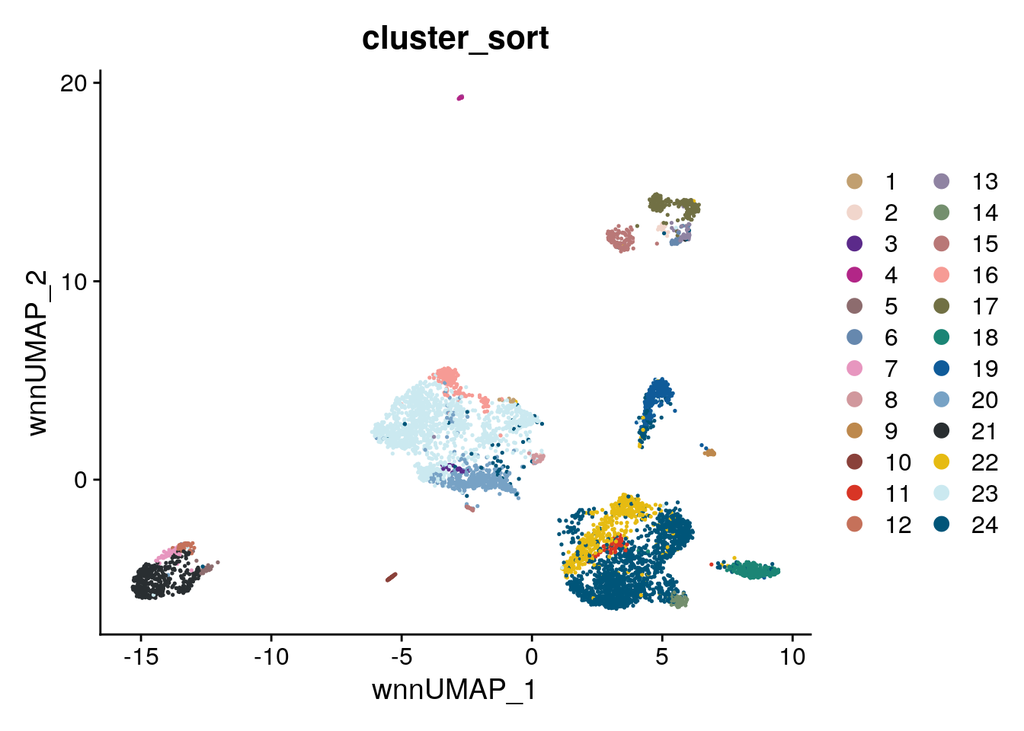

```r
# Label cluster according to cluster size
cluster.cnt <- sort(table(sc_object$cluster))
sc_object$cluster_sort = factor(as.character(sc_object$cluster), levels=names(cluster.cnt),
                                labels = 1:length(cluster.cnt), ordered = T)

# Define color palette for visualization
cols <- c("#532C8A","#c19f70","#f9decf","#c9a997","#B51D8D","#9e6762","#3F84AA","#F397C0",
          "#C594BF","#DFCDE4","#eda450","#635547","#C72228","#EF4E22","#f77b59","#989898",
          "#7F6874","#8870ad","#65A83E","#EF5A9D","#647a4f","#FBBE92","#354E23","#139992",
          "#C3C388","#8EC792","#0F4A9C","#8DB5CE","#1A1A1A","#FACB12","#C9EBFB","#DABE99",
          "#ed8f84","#005579","#CDE088","#BBDCA8","#F6BFCB"
)

getPalette = colorRampPalette(cols[c(2,3,1,5,6,7,8,9,11,12,13,14,16,18,19,20,22,23,24,27,28,29,30,31,34)])

# UMAP visualization of RareQ-identified clusters based on WNN embedding
DimPlot(sc_object, group.by='cluster_sort', reduction = 'wnn.umap') +
  scale_color_manual(values = getPalette(length(unique(sc_object$cluster_sort))))
```